# Crecimiento logístico

6 de marzo de 2019

## Contenido

- Teoría del crecimiento logístico
- Detalles para el Taller de Gestión de datos
- Dudas con instalación del ambiente de trabajo III.
- Paso a paso del tutorial con **R**.
- Tarea 01. Dudas
- Metas para la próxima semana

## Deducción del Modelo logístico

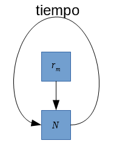

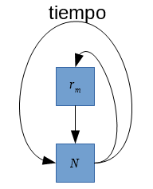

Existe retroalimentación en el modelo logístico.

## Deducción del Modelo logístico

El tamaño de la población **influye** en la tasa de crecimiento intrínseco (\(r_m\)).

- Competencia.
- Disminución de alimento *per cápita*.
- Emigración.
- Enfermedades.

## Deducción del Modelo logístico

Esto quiere decir que \(r_m\) ya no es una constante.

- Ahora varía con respecto al tamaño de población.
- Por consiguiente, varía en el tiempo.

Decimos que \(\mathrm{r_m}\) está en función de \(N_t\):

\[ r_m = f \left( N_t \right) \]

## Deducción del Modelo logístico

**Requerimientos de** \(f \left( N_t \right)\):

- Debe llegar a un límite de tamaño de población.
- Debe crecer rápido al inicio.
- Debe detener el crecimiento tras alcanzar el límite de tamaño.

## Deducción del Modelo logístico

\[ r_m = \mathrm{r_m}\left(1-\frac{N_t}{K}\right) \]

**Ejercicio**

- ¿Qué pasa cuando \(N_t \to 0\)?
- ¿Qué pasa cuando \(N_t \to K\)?

## Deducción del Modelo logístico

Abrir **RStudio**, `File --> New File --> R Script`

```r
rm <- 1; K <- 100; N <- 0:100

val <- rm * (1 - (N / K))

plot(N,  val,  type = "l", las = 1, lwd = 2,
  xlab = "Tamaño de población", ylab = expression(r[m])
  )
```

[figure not shown]

## Deducción del Modelo logístico

Observamos que esa expresión si cumple con los requisitos. Entonces remplazamos esta expresión por la tasa intrínseca de crecimiento en nuestra función del crecimiento exponencial.

\[ \frac{dN}{dt}=\mathrm{r_m} N_t \left(1-\frac{N_t}{K}\right) \]

## Ejercicio

Grafique la expresión

\[ \frac{dN}{dt}=\mathrm{r_m} N_t \left(1-\frac{N_t}{K}\right) \]

En función de \(N_t\). Utilice como base el código anterior.

## Respuesta

```r
rm <- 1; K <- 100; N <- 0:100

val <- rm * (1 - (N / K))*N

plot(N,val,  type = "l", las = 1, lwd = 2,
     xlab = "Tamaño de población",ylab = expression(dN/dt)
  )
```

[figure not shown]

## Deducción del crecimiento logístico

La expresión anterior es otra ecuación diferencial. Utilizando el método de *separación de variables*, podemos resolver esa expresión para conocer \(N\) en función del tiempo.

\[ N_t= \frac{K}{1+\left(\frac{K}{N_0}-1\right)e^{-rt}} \]

- ¿Qué pasa cuando \(t \to \infty\)
- ¿Qué pasa cuando \(t \to 0\)

## Deducción del crecimiento logístico

[figure not shown]

Crecimiento logístico, con capacidad de carga igual a cien individuos

## ¿Cuándo es máximo el crecimiento?

Esto constituye un problema de máximos. Tiene una solución análitica, que consiste en encontrar los puntos críticos de la función. Y evaluar \(f'(x)=0\).

En este caso, necesitamos resolver:

\[ D\left[ \mathrm{r_m}N_t\left(1-\frac{N_t}{K}\right)\right]=0 \]

Y al hacerlo encontramos que el máximo crecimiento se obtiene cuando:

\[ N_t = \frac{K}{2} \]

## ¿Cuál es el mayor crecimiento de una población?

Ahora que sabemos cuándo obtenemos el mayor crecimiento, reemplazamos \(N_t = \frac{K}{2}\) en:

\[ \frac{dN}{dt}=\mathrm{r_m} N_t \left(1-\frac{N_t}{K}\right) \]

Donde obtenemos que el máximo crecimiento es igual a

\[ \frac{\mathrm{r_m}K}{4} \]

## Cosecha de poblaciones

Una de las aplicaciones más ampliamente utilizadas, y criticadas, de los *modelos logísticos* es su uso para calcular cuántos individuos (o biomasa) puede ser extraída de una población, sin provocar un crecimiento **negativo**.

Si sabemos que:

> Tamaño de población = Tamaño anterior + Crecimiento

Entonces la premisa es que podemos cosechar una cantidad no mayor al crecimiento, y la población logrará recuperarse.

## Máximo Rendimiento Sostenible

Se define como el **crecimiento máxmimo que una población puede producir, bajo una capacidad de carga determinada. Ésta es la cantidad máxima de individuos, o biomasa, que se puede extraer de una población, sin provocar un crecimiento negativo.**

Ya hemos calculado sus valores:

\[ \begin{split} N_{MRS} &= \frac{K}{2}\\ MRS &= \frac{r_m K}{4} \end{split} \]

## Parámetros de cosecha

[figure not shown]

## Ejercicio

Suponga que existe un tanque sobre una balanza. Este tanque contiene aguas residuales, que son limpiadas por una pequeña planta del genero *Lemna*. El flujo del tanque es tal, que la masa del agua siempre se mantiene constante; de modo que la balanza solo mide el crecimiento de *Lemna*. Nos interesa mantener una población de Lemna con un rápido crecimiento; ya que éste es proporcional a la tasa de extracción de toxinas del tanque. El tanque inicia con 1 kg de *Lemna*, con una tasa de crecimiento es de \(5\times 10 ^{-6}\text{s}^{-1}\). Además, se ha determinado que el tanque solo soporta 100 kg de *Lemna*. ¿Cuál es el tamaño de población de *Lemna* que debería haber en el tanque para maximizar el crecimiento? ¿Cuánta biomasa debe extraer **en un día** para mantener un máximo de crecimiento? ¿A qué biomasa total debería cosechar la *Lemna*?

## Definir fecha para taller de gestión de datos

## Instrucciones y cronograma de exposiciones individuales

## Inducción a la gira de RNVSPH-PM

## Paso a paso del tutorial con **Rmarkdown**

## Tarea 01. Dudas

## Metas para la próxima semana

- Entregar la Tarea 01. **Fecha límite** 2018-03-13 (YYYY-MM-DD), 23:59 horas.
- Entregar la Tarea 02. **Fecha límite** 2018-03-20 (YYYY-MM-DD), 23:59 horas.
- Instalar **Git**.
- Aún faltan personas por aceptar invitación en el foro.
- Hay poca participación.